# Data visualization NECK trial

Ilse van Beelen & Floor Komen

11/27/2019

Goal of this script is to visualize the raw data, histograms and correlations between different variables

# Set up

```r
rm(list = ls())
#library(ggplot2)
library(tidyverse)
library(gridExtra)
df_long <- read.csv("Data/data_final_2019-11-05.csv", sep = ",")
df_prediction <- read.csv("Data/data_final_prediction_2019-11-05.csv", sep = ",")


df_long$time_fct <- as.factor(df_long$time_fct)
df_prediction$time_fct <- as.factor(df_prediction$time_fct)

# Set layout for all figures
theme <- theme(panel.background = element_blank(),
          panel.grid.major = element_line(colour = "darkgrey", size=0.5),
          panel.grid.minor = element_line(colour = "grey",
                                          size=.25,
                                          linetype = "dashed"),
          panel.border = element_blank(),
          axis.line.x = element_line(colour = "black",
                                     size=0.5,
                                     lineend = "butt"),
          axis.line.y = element_line(colour = "black",
                                     size=0.5),
          axis.text=element_text(size=15),
              axis.title=element_text(size=22),
              plot.title = element_text(size = 22),
              strip.text = element_text(size = 15),
              legend.title = element_blank())
```

# Data summary

We have 109 patients who are randomly assigned to 3 different surgeries (ACD, ACDF, ACDA). The NDI, HADS depression and HADS anxiety are measured at baseline, 1 year and 2 years after surgery. An earlier analysis of the data showed that the functional recovery measured, NDI, is not significantly different between the three surgeries.

# Data visualization

## NDI over time

Below, the NDI score is visualized for each patient over time. In general, there is a decreasing trend over time. Except for a few subjects where the NDI increases over time.

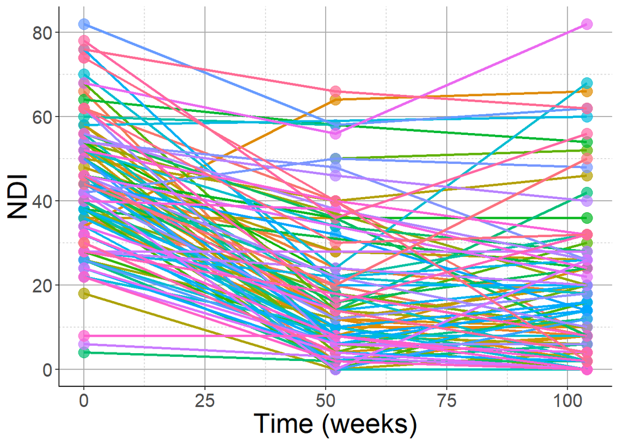

```r
p1 <-  ggplot(data = df_long, aes(x = time, y = ndi, col = id))  +
  geom_point(size = 4, alpha = 0.7) +
  geom_line(aes(group = id), size = 1) +
  #ggtitle("Raw data: NDI score over time") +
  ylab("NDI") +
  xlab("Time (weeks)") + theme(legend.position = "none") +
  theme

plot(p1)
```

```r
png("Figures/NDI_raw.png",width = 15, height = 7, units='in',res=300)
plot(p1)
dev.off()
```

### Demographics

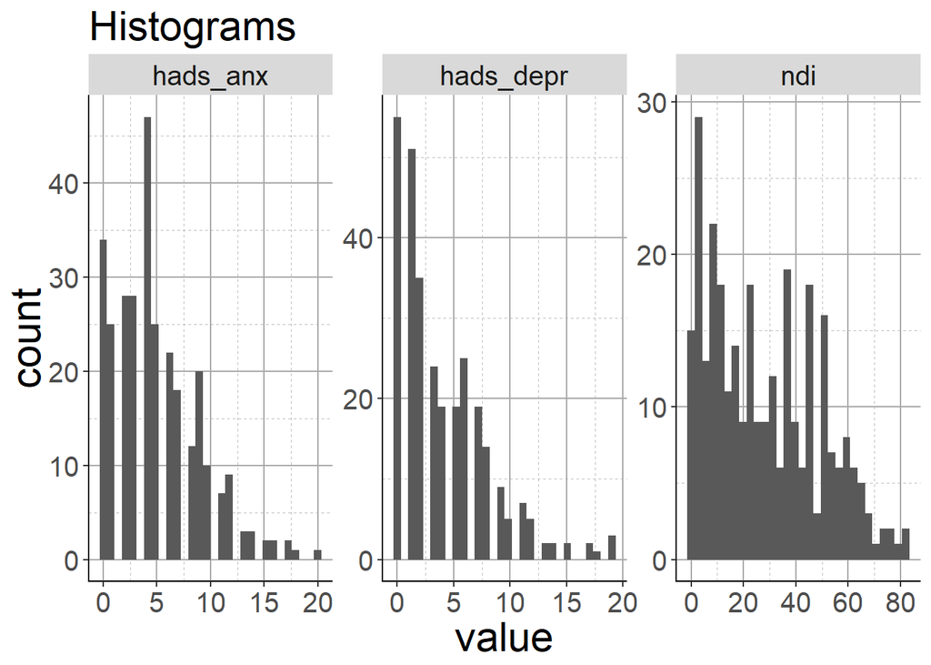

```r
p_demo <- df_long %>%
  dplyr::select(ndi, hads_depr, hads_anx) %>%
  gather() %>%
  ggplot(aes(value)) +
    facet_wrap(~ key, scales = "free") +
    geom_histogram(bins = 30) + theme +
  ggtitle("Histograms")

plot(p_demo)
```

```r
png("Figures/Histograms.png",width = 15, height = 7, units='in',res=300)
plot(p_demo)
dev.off()
```

# Correlations between NDI and HADS anx/depres at different time points

Correlation between NDI score and HADS anxiety score at baseline, 52 and 104 weeks

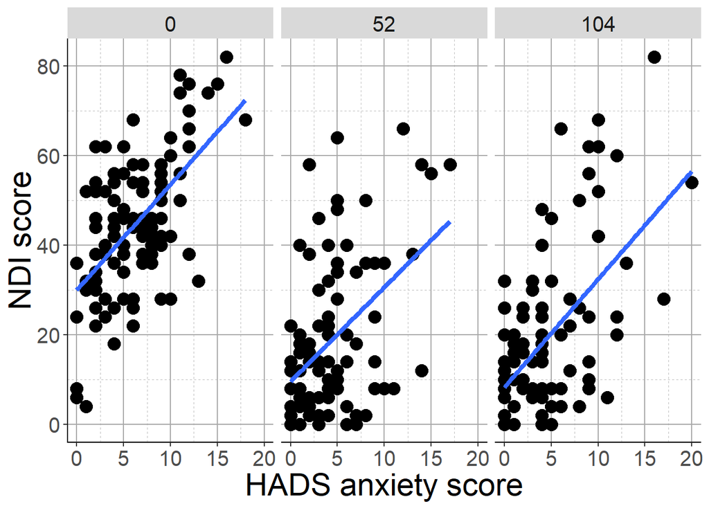

```r
ggplot(data = df_long, aes(x = hads_anx, y = ndi)) +
  geom_point(size = 4) + geom_smooth(method=lm, se = F, size = 1.5) +
  facet_grid(~time) + theme +
  xlab("HADS anxiety score") + ylab("NDI score")
```

Correlation between NDI score and HADS depression score at baseline, 52 and 104 weeks

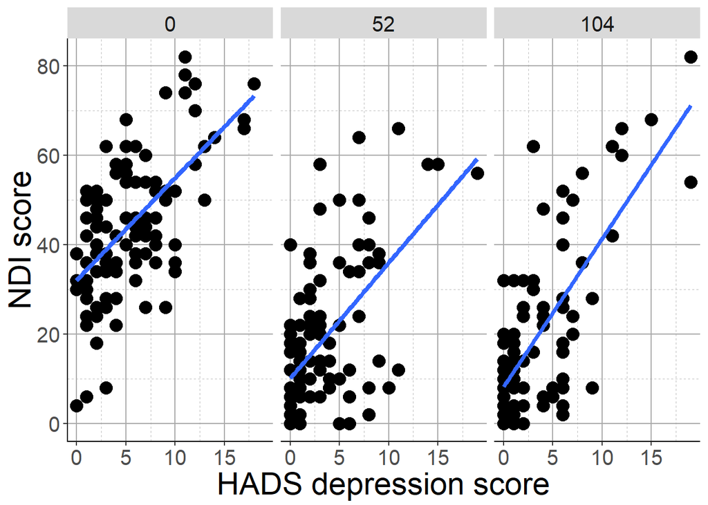

```r
ggplot(data = df_long, aes(x = hads_depr, y = ndi)) +
  geom_point(size = 4) + geom_smooth(method=lm, se = F, size = 1.5) +
  facet_grid(~time) + theme +
  xlab("HADS depression score") + ylab("NDI score")
```

Correlation between HADS anxiety and HADS depression score at baseline, 52 and 104 weeks

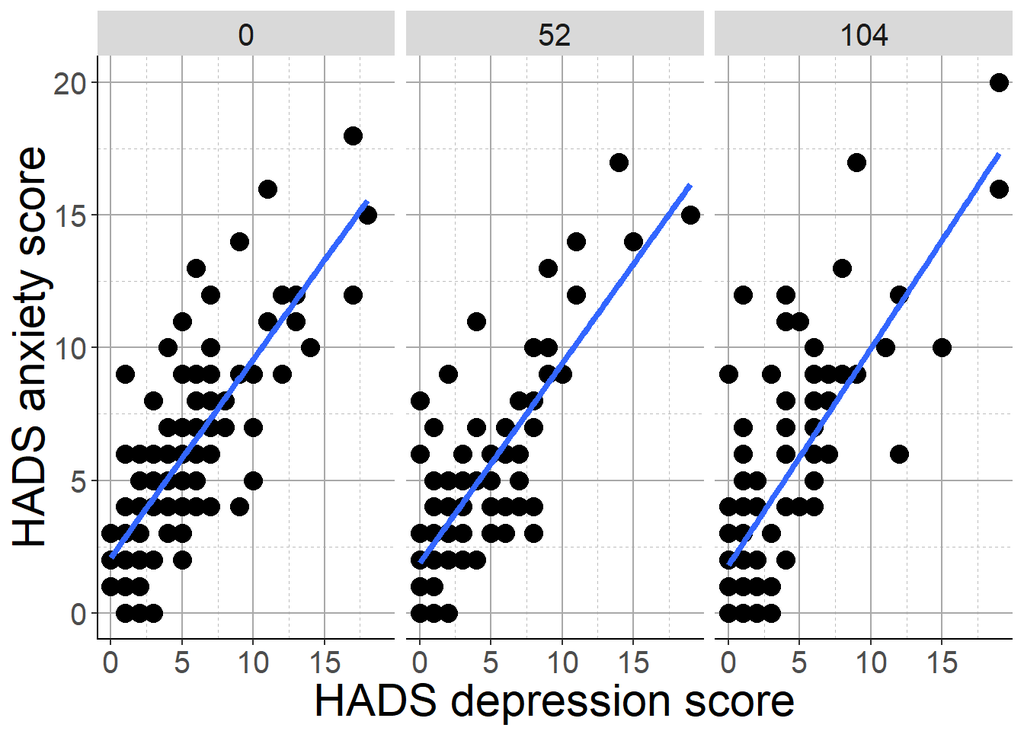

```r
ggplot(data = df_long, aes(x = hads_depr, y = hads_anx)) +
  geom_point(size = 4) + geom_smooth(method=lm, se = F, size = 1.5) +
  facet_grid(~time) + theme +
  xlab("HADS depression score") + ylab("HADS anxiety score")
```

# Correlation between NDI scores at different time points

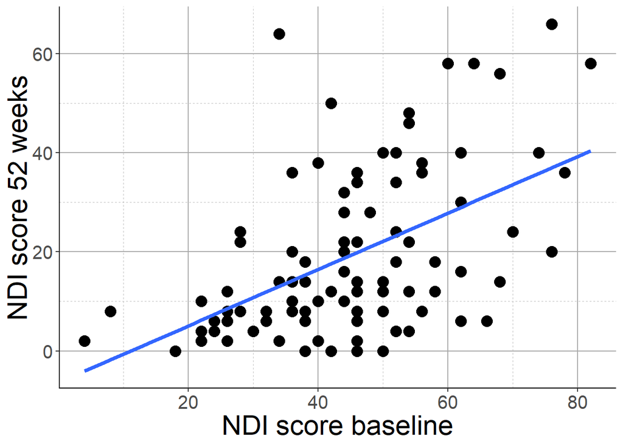

```r
# Correlation between NDI at baseline and after 1 year. And correlation between NDI at baseline and after 2 years.
df_corr <- df_long %>%
  select(id, time, ndi) %>%
  spread(key = time, value = ndi, sep = "_ndi")

df_corr2 <- df_long %>%
  select(id, time, hads_tot) %>%
  spread(key = time, value = hads_tot, sep = "_hads")


df_corr <- left_join(df_corr, df_corr2, "id")


p3 <- ggplot(data = df_corr, aes(x = time_ndi0 , y = time_ndi52)) +
  geom_point(size = 4) + geom_smooth(method=lm, se = F, size = 1.5) +
  xlab("NDI score baseline") + ylab("NDI score 52 weeks") + theme

plot(p3)
```

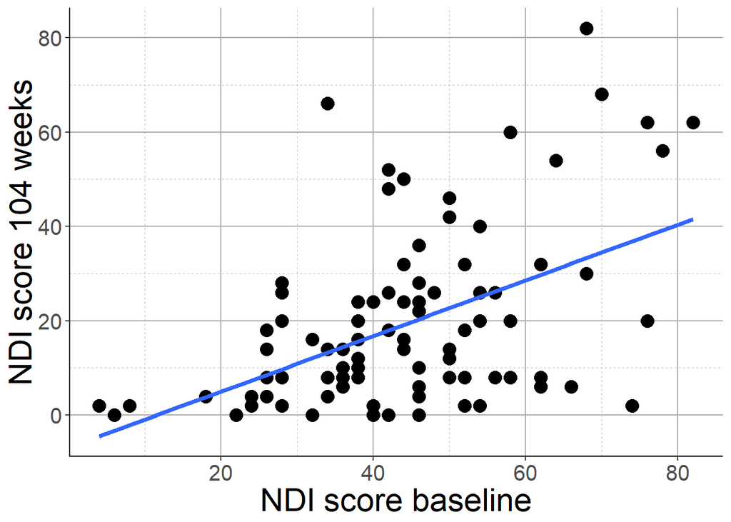

```r
p4 <- ggplot(data = df_corr, aes(x = time_ndi0 , y = time_ndi104)) +
  geom_point(size = 4) + geom_smooth(method=lm, se = F, size = 1.5) +

  xlab("NDI score baseline") + ylab("NDI score 104 weeks") + theme

plot(p4)
```

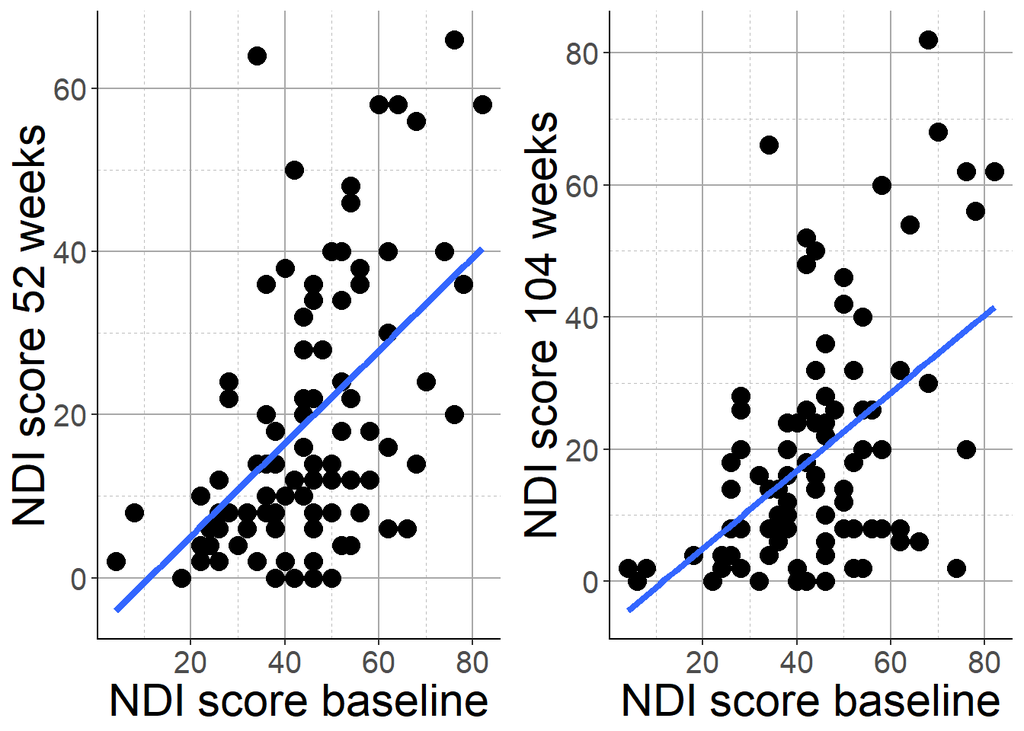

```r
grid.arrange(p3, p4, nrow = 1)
```